# Regression

Published

September 6, 2023

Note: This file is greatly based on the material prepared by Julian Langer and Lachlan Deer for the programming course for previous years ## Libraries

```r
library(dplyr)      # data manipulation
library(tibble)     # nicer dataframes
library(fixest)     # Regression
library(modelsummary) # tables
library(readxl)
library(vtable) # summary table
```

### Import data

We will replicate some regressions in [this paper](https://www.aeaweb.org/articles?id=10.1257/aer.98.3.808).

```r
ajry_df = read_xls("../Datasets/ajry.xls", sheet = 2) %>%
  arrange(code_numeric, year_numeric) %>%
  rename(log_gdp_pc = lrgdpch,
         freedom_house = fhpolrigaug)
```

### Summary statistics

First lets create a table with the summary statistics of the variables and export it to latex

```r
st(ajry_df, vars = c('freedom_house','log_gdp_pc','education','laborshare'), out='latex',file='mytable1.tex')
```

```
\begin{table}[!htbp] \centering \renewcommand*{\arraystretch}{1.1}\caption{Summary Statistics}\resizebox{\textwidth}{!}{
\begin{tabular}{lrrrrrrr}
\hline
\hline
Variable & N & Mean & Std. Dev. & Min & Pctl. 25 & Pctl. 75 & Max \\
\hline
freedom\_house & 1517 & 0.51 & 0.36 & 0 & 0.17 & 0.83 & 1 \\
log\_gdp\_pc & 1231 & 8.1 & 1 & 5.8 & 7.3 & 8.9 & 11 \\
education & 818 & 4.3 & 2.9 & 0.042 & 1.9 & 6.5 & 12 \\
laborshare & 539 & 0.37 & 0.13 & 0.076 & 0.26 & 0.47 & 0.74\\
\hline
\hline
\end{tabular}
}
\end{table}
```

Let’s created lagged vbles

```r
# generate lagged variables
ajry_df = ajry_df %>%
  group_by(code_numeric) %>%
  mutate(lag_log_gdp_pc = lag(log_gdp_pc, order_by = year_numeric),
         lag_freedom_house = lag(freedom_house, order_by = year_numeric),
         lag2_nsave = lag(nsave, 2, order_by = year_numeric),
         lag_worldincome = lag(worldincome, order_by = year_numeric)) %>%
  filter(sample == 1)
```

### Regressions

Now let’s start with a simple OLS regression. The simplest way to do this is using the ‘lm’ command, but it does not allow for a lot of flexibility. So we’ll just use it once here and then change to using the commands in the fixest package

```r
OLS1 = lm(freedom_house ~ lag_freedom_house + lag_log_gdp_pc, data = ajry_df)
summary(OLS1)
```

```
Call:
lm(formula = freedom_house ~ lag_freedom_house + lag_log_gdp_pc,
    data = ajry_df)

Residuals:
     Min       1Q   Median       3Q      Max
-0.89549 -0.10235  0.00481  0.09141  0.79342

Coefficients:
                   Estimate Std. Error t value Pr(>|t|)
(Intercept)       -0.475361   0.059881  -7.938  5.8e-15 ***
lag_freedom_house  0.691761   0.023513  29.421  < 2e-16 ***
lag_log_gdp_pc     0.080127   0.008232   9.734  < 2e-16 ***
---
Signif. codes:  0 '***' 0.001 '**' 0.01 '*' 0.05 '.' 0.1 ' ' 1

Residual standard error: 0.1968 on 942 degrees of freedom
  (424 observations deleted due to missingness)
Multiple R-squared:  0.7075,    Adjusted R-squared:  0.7069
F-statistic:  1139 on 2 and 942 DF,  p-value: < 2.2e-16
```

```r
# Checking frequency by group
#table(ajry_df %>% group_by(country,year) %>% count())
```

**FEOLS package**

We will be using the feols command from the fixest package. Seems to be the fastest option available: https://lrberge.github.io/fixest/

The basic synyax of feols is: **feols(dependent_var ~ independent_vars | fixed effects | IV_formula, cluster/vcov , data = my_data)**

Let’s just replicate the regression we ran in the line above:

```r
FE1 = feols(freedom_house ~ lag_freedom_house + lag_log_gdp_pc, data = ajry_df)
```

```
NOTE: 424 observations removed because of NA values (LHS: 103, RHS: 422).
```

```r
summary(FE1)
```

```
OLS estimation, Dep. Var.: freedom_house
Observations: 945
Standard-errors: IID
                   Estimate Std. Error  t value   Pr(>|t|)
(Intercept)       -0.475361   0.059881 -7.93844 5.8003e-15 ***
lag_freedom_house  0.691761   0.023513 29.42066  < 2.2e-16 ***
lag_log_gdp_pc     0.080127   0.008232  9.73351  < 2.2e-16 ***
---
Signif. codes:  0 '***' 0.001 '**' 0.01 '*' 0.05 '.' 0.1 ' ' 1
RMSE: 0.196442   Adj. R2: 0.706873
```

Now let’s add year fixed effects to the regression. Note that the std errors are clustered at the level of the FE if we do not specify anything

```r
FE2 = feols(freedom_house ~  lag_freedom_house + lag_log_gdp_pc  | year_numeric , vcov='hetero', data = ajry_df)
```

```
NOTE: 424 observations removed because of NA values (LHS: 103, RHS: 422).
```

```r
summary(FE2)
```

```
OLS estimation, Dep. Var.: freedom_house
Observations: 945
Fixed-effects: year_numeric: 9
Standard-errors: Heteroskedasticity-robust
                  Estimate Std. Error  t value   Pr(>|t|)
lag_freedom_house 0.706370   0.028401 24.87145  < 2.2e-16 ***
lag_log_gdp_pc    0.072318   0.009380  7.70992 3.2167e-14 ***
---
Signif. codes:  0 '***' 0.001 '**' 0.01 '*' 0.05 '.' 0.1 ' ' 1
RMSE: 0.190421     Adj. R2: 0.722207
                 Within R2: 0.710227
```

Lets add country fixed effects and cluster at the country level

```r
FE3 = feols(freedom_house ~ lag_freedom_house + lag_log_gdp_pc | year_numeric + code_numeric , cluster = c('code'), data = ajry_df)
```

```
NOTE: 424 observations removed because of NA values (LHS: 103, RHS: 422).
```

```r
summary(FE3)
```

```
OLS estimation, Dep. Var.: freedom_house
Observations: 945
Fixed-effects: year_numeric: 9,  code_numeric: 150
Standard-errors: Clustered (code)
                  Estimate Std. Error  t value   Pr(>|t|)
lag_freedom_house 0.378628   0.046692 8.108995 1.7291e-13 ***
lag_log_gdp_pc    0.010415   0.031673 0.328830 7.4275e-01
---
Signif. codes:  0 '***' 0.001 '**' 0.01 '*' 0.05 '.' 0.1 ' ' 1
RMSE: 0.164093     Adj. R2: 0.754557
                 Within R2: 0.143609
```

**Additional features**

**HC3 std errors** Now let’s compute HC3 standard errors

```r
FE_HC1 = feols(freedom_house ~  lag_freedom_house + lag_log_gdp_pc  + i(year_numeric) , vcov = function(x) sandwich::vcovHC(x, type = "HC1"), data = ajry_df)
```

```
NOTE: 424 observations removed because of NA values (LHS: 103, RHS: 422).
```

```r
FE_HC3 = feols(freedom_house ~  lag_freedom_house + lag_log_gdp_pc  + i(year_numeric) , vcov = function(x) sandwich::vcovHC(x, type = "HC3"), data = ajry_df)
```

```
NOTE: 424 observations removed because of NA values (LHS: 103, RHS: 422).
```

```r
modelsummary(list(FE_HC1,FE_HC3))
```

|  | Model 1 | Model 2 |
| --- | --- | --- |
| (Intercept) | −0.347 | −0.347 |
|  | (0.063) | (0.064) |
| lag_freedom_house | 0.706 | 0.706 |
|  | (0.028) | (0.029) |
| lag_log_gdp_pc | 0.072 | 0.072 |
|  | (0.009) | (0.009) |
| year_numeric = 34 | −0.083 | −0.083 |
|  | (0.021) | (0.021) |
| year_numeric = 35 | −0.199 | −0.199 |
|  | (0.030) | (0.030) |
| year_numeric = 36 | −0.112 | −0.112 |
|  | (0.025) | (0.026) |
| year_numeric = 37 | −0.050 | −0.050 |
|  | (0.027) | (0.027) |
| year_numeric = 38 | −0.073 | −0.073 |
|  | (0.024) | (0.025) |
| year_numeric = 39 | −0.053 | −0.053 |
|  | (0.022) | (0.022) |
| year_numeric = 40 | −0.032 | −0.032 |
|  | (0.027) | (0.027) |
| year_numeric = 41 | −0.056 | −0.056 |
|  | (0.021) | (0.021) |
| Num.Obs. | 945 | 945 |
| R2 | 0.725 | 0.725 |
| R2 Adj. | 0.722 | 0.722 |
| AIC | −428.8 | −428.8 |
| BIC | −370.6 | −370.6 |
| RMSE | 0.19 | 0.19 |
| Std.Errors | vcovHC(x, type = "HC1") | vcovHC(x, type = "HC3") |

**Adding many variables w/ same pattern**

Now lets assume we want to include all the variables starting with the word ‘lag’ in the regression:

```r
library(stringr)

stringv = str_split(str_subset(colnames(ajry_df), 'lag'),  pattern = " ")

feols(as.formula(paste('freedom_house ~ i(year_numeric) + ',  paste(stringv, collapse = " + "), sep = '')) , data=ajry_df)
```

```
NOTE: 511 observations removed because of NA values (LHS: 103, RHS: 509).
```

```
OLS estimation, Dep. Var.: freedom_house
Observations: 858
Standard-errors: IID
                  Estimate Std. Error  t value   Pr(>|t|)
(Intercept)      -0.392371   0.073238 -5.35746 1.0890e-07 ***
year_numeric::34 -0.068742   0.040499 -1.69736 8.9996e-02 .
year_numeric::35 -0.206552   0.037891 -5.45117 6.5703e-08 ***
year_numeric::36 -0.123028   0.037583 -3.27353 1.1053e-03 **
year_numeric::37 -0.059499   0.037387 -1.59143 1.1189e-01
year_numeric::38 -0.092766   0.037082 -2.50162 1.2551e-02 *
year_numeric::39 -0.064544   0.036712 -1.75813 7.9087e-02 .
year_numeric::40 -0.042775   0.036571 -1.16966 2.4247e-01
... 5 coefficients remaining (display them with summary() or use argument n)
---
Signif. codes:  0 '***' 0.001 '**' 0.01 '*' 0.05 '.' 0.1 ' ' 1
RMSE: 0.192505   Adj. R2: 0.716508
```

How many countries to we have

```r
#n_distinct(ajry_df$code)
#unique(ajry_df$code)
```

**Instrumental variables**

Now let’s add instruments

```r
ajry_df = ajry_df %>% group_by(country) %>% mutate(lag2_nsave = lag(nsave , 2, order_by = year_numeric))

IV1 = feols(freedom_house ~ lag_freedom_house
            | year_numeric + country
            | lag_log_gdp_pc ~ lag2_nsave, cluster = c('country') ,
            #dof = dof(fixef.K = 'full'),
            data = ajry_df)
```

```
NOTE: 672 observations removed because of NA values (LHS: 103, RHS: 123, IV: 403/662).
```

```r
summary(IV1)
```

```
TSLS estimation, Dep. Var.: freedom_house, Endo.: lag_log_gdp_pc, Instr.: lag2_nsave
Second stage: Dep. Var.: freedom_house
Observations: 697
Fixed-effects: year_numeric: 7,  country: 126
Standard-errors: Clustered (country)
                    Estimate Std. Error   t value   Pr(>|t|)
fit_lag_log_gdp_pc -0.036075   0.112316 -0.321192 7.4860e-01
lag_freedom_house   0.322222   0.052170  6.176368 8.4762e-09 ***
---
Signif. codes:  0 '***' 0.001 '**' 0.01 '*' 0.05 '.' 0.1 ' ' 1
RMSE: 0.16891     Adj. R2: 0.736829
                Within R2: 0.097935
F-test (1st stage), lag_log_gdp_pc: stat = 95.8     , p < 2.2e-16 , on 1 and 688 DoF.
                        Wu-Hausman: stat =  0.046601, p = 0.829165, on 1 and 562 DoF.
```

## Retrieving the regression results

Frequently, we want to do something with the results of the regressions. For this we have to know where R stores the coefficients, standard errors, etc.

First let’s have a look at the coefficients:

```r
FE1$coefficients['lag_freedom_house']
```

```
lag_freedom_house
        0.6917614
```

```r
FE1$coefficients[2]
```

```
lag_freedom_house
        0.6917614
```

If I want to see the first stage results:

```r
IV1$iv_first_stage
```

```
$lag_log_gdp_pc
TSLS estimation, Dep. Var.: lag_log_gdp_pc, Endo.: lag_log_gdp_pc, Instr.: lag2_nsave
First stage: Dep. Var.: lag_log_gdp_pc
Observations: 697
Fixed-effects: year_numeric: 7,  country: 126
Standard-errors: Clustered (country)
                  Estimate Std. Error  t value   Pr(>|t|)
lag2_nsave        1.185028   0.241330 4.910409 2.7819e-06 ***
lag_freedom_house 0.026514   0.053508 0.495512 6.2111e-01
---
Signif. codes:  0 '***' 0.001 '**' 0.01 '*' 0.05 '.' 0.1 ' ' 1
RMSE: 0.175699     Adj. R2: 0.965026
                 Within R2: 0.123007
F-test (1st stage): stat = 95.8, p < 2.2e-16, on 1 and 688 DoF.
```

## Post-estimation tests

```r
library(aod)
wald.test(Sigma = vcov(FE_HC3), b=coef(FE_HC3), Terms = 1:2)
```

```
Wald test:
----------

Chi-squared test:
X2 = 1317.5, df = 2, P(> X2) = 0.0
```

Now lets assume we want to test whether beta1 = beta2

```r
wald.test(Sigma = vcov(FE2), b=coef(FE2), L = matrix(c(-1,1),1,2))
```

```
Wald test:
----------

Chi-squared test:
X2 = 304.1, df = 1, P(> X2) = 0.0
```

## Exporting the results to a regression table

To export the results to Latex, we will use the package “modelsummary”

```r
library(modelsummary)
modelsummary(OLS1)
```

|  | Model 1 |
| --- | --- |
| (Intercept) | −0.475 |
|  | (0.060) |
| lag_freedom_house | 0.692 |
|  | (0.024) |
| lag_log_gdp_pc | 0.080 |
|  | (0.008) |
| Num.Obs. | 945 |
| R2 | 0.707 |
| R2 Adj. | 0.707 |
| AIC | −386.0 |
| BIC | −366.6 |
| Log.Lik. | 196.985 |
| RMSE | 0.20 |

Now assume how we want to make a table with the results of all the regressions that we have run

```r
listmodels = list('OLS' = FE1,
                  'FE1' = FE2,
                  'FE2' = FE3,
                  'IV' = IV1)

modelsummary(listmodels)
```

|  | OLS | FE1 | FE2 | IV |
| --- | --- | --- | --- | --- |
| (Intercept) | −0.475 |  |  |  |
|  | (0.060) |  |  |  |
| lag_freedom_house | 0.692 | 0.706 | 0.379 | 0.322 |
|  | (0.024) | (0.028) | (0.047) | (0.052) |
| lag_log_gdp_pc | 0.080 | 0.072 | 0.010 |  |
|  | (0.008) | (0.009) | (0.032) |  |
| fit_lag_log_gdp_pc |  |  |  | −0.036 |
|  |  |  |  | (0.112) |
| Num.Obs. | 945 | 945 | 945 | 697 |
| R2 | 0.707 |  |  |  |
| R2 Adj. | 0.707 |  |  |  |
| AIC | −386.0 | −446.8 | −728.0 | −495.1 |
| BIC | −366.6 | −432.3 | −713.5 | −481.4 |
| RMSE | 0.20 | 0.19 | 0.16 | 0.17 |
| Std.Errors | IID | Heteroskedasticity-robust | by: code | by: country |
| FE: year_numeric |  | X | X | X |
| FE: code_numeric |  |  | X |  |
| FE: country |  |  |  | X |

```r
cm = c('lag_freedom_house' = 'Democracy$_{t-1}$',
       'lag_log_gdp_pc' = 'LogGDP$_{t-1}$',
       'fit_lag_log_gdp_pc' = 'LogGDP$_{t-1}$',
       '(Intercept)' = 'Constant')

modelsummary(listmodels, coef_map = cm)
```

|  | OLS | FE1 | FE2 | IV |
| --- | --- | --- | --- | --- |
| Democracy$_{t-1}$ | 0.692 | 0.706 | 0.379 | 0.322 |
|  | (0.024) | (0.028) | (0.047) | (0.052) |
| LogGDP$_{t-1}$ | 0.080 | 0.072 | 0.010 | −0.036 |
|  | (0.008) | (0.009) | (0.032) | (0.112) |
| Constant | −0.475 |  |  |  |
|  | (0.060) |  |  |  |
| Num.Obs. | 945 | 945 | 945 | 697 |
| R2 | 0.707 |  |  |  |
| R2 Adj. | 0.707 |  |  |  |
| AIC | −386.0 | −446.8 | −728.0 | −495.1 |
| BIC | −366.6 | −432.3 | −713.5 | −481.4 |
| RMSE | 0.20 | 0.19 | 0.16 | 0.17 |
| Std.Errors | IID | Heteroskedasticity-robust | by: code | by: country |
| FE: year_numeric |  | X | X | X |
| FE: code_numeric |  |  | X |  |
| FE: country |  |  |  | X |

Now assume that we do not want to keep all the statistics of the regression that we see on the table above. Let’s assume that we only want to keep the number of Obs, Adjusted R^2 and that we want to change the text for the Std errors and the FE

```r
# raw: a string with the name of a column produced by broom::glance(model) or get_gof(model)
#clean: a string with the “clean” name of the statistic you want to appear in your final table.
#fmt: a string which will be used to round/format the string in question (e.g., "%.3f"). This follows the same standards as the fmt argument in ?modelsummary.
get_gof(FE3)
```

```
        aic      bic      rmse nobs FE: year_numeric FE: code_numeric vcov.type
1 -728.0416 -713.488 0.1640933  945                X                X  by: code
```

```r
stat_table = tribble(~raw, ~clean, ~fmt, # See for tribble function https://tibble.tidyverse.org/reference/tribble.html
                     'adj.r.squared', 'Adj.R$2$',2,
                     'nobs', 'N', 0,
                     'vcov.type', 'Std Errors', 0,
                     'FE: year_numeric', 'Year FE', 0,
                     'FE: code_numeric', 'Country FE', 0
                     )
modelsummary(listmodels, coef_map = cm, gof_map = stat_table)
```

|  | OLS | FE1 | FE2 | IV |
| --- | --- | --- | --- | --- |
| Democracy$_{t-1}$ | 0.692 | 0.706 | 0.379 | 0.322 |
|  | (0.024) | (0.028) | (0.047) | (0.052) |
| LogGDP$_{t-1}$ | 0.080 | 0.072 | 0.010 | −0.036 |
|  | (0.008) | (0.009) | (0.032) | (0.112) |
| Constant | −0.475 |  |  |  |
|  | (0.060) |  |  |  |
| Adj.R$2$ | 0.71 |  |  |  |
| N | 945 | 945 | 945 | 697 |
| Std Errors | IID | Heteroskedasticity-robust | by: code | by: country |
| Year FE |  | X | X | X |
| Country FE |  |  | X |  |

Lets add new rows to the table and stars

```r
rows = tribble(~term,~m1,~m2,~m3, ~m4,
               'Std errors', 'Homosk', 'Heterosk-Robust', 'Clustered','Clustered')

stat_table = tribble(~raw, ~clean, ~fmt, # See for tribble function https://tibble.tidyverse.org/reference/tribble.html
                     'adj.r.squared', 'Adj.R$2$',2,
                     'nobs', 'N', 0,
                     'FE: year_numeric', 'Year FE', 0,
                     'FE: code_numeric', 'Country FE', 0
                     )


modelsummary(listmodels, coef_map = cm, gof_map = stat_table, stars = c('*' = 0.1 , '**'=0.05, '***'=0.01),  add_rows = rows)
```

|  | OLS | FE1 | FE2 | IV |
| --- | --- | --- | --- | --- |
| Democracy$_{t-1}$ | 0.692*** | 0.706*** | 0.379*** | 0.322*** |
|  | (0.024) | (0.028) | (0.047) | (0.052) |
| LogGDP$_{t-1}$ | 0.080*** | 0.072*** | 0.010 | −0.036 |
|  | (0.008) | (0.009) | (0.032) | (0.112) |
| Constant | −0.475*** |  |  |  |
|  | (0.060) |  |  |  |
| Adj.R$2$ | 0.71 |  |  |  |
| N | 945 | 945 | 945 | 697 |
| Year FE |  | X | X | X |
| Country FE |  |  | X |  |
| Std errors | Homosk | Heterosk-Robust | Clustered | Clustered |

Exporting tables to Latex:

```r
if (!dir.exists('out_tex')){
  dir.create('out_tex')
}

modelsummary(listmodels, coef_map = cm,
             gof_map = stat_table,
             stars = c('*' = 0.1 , '**'=0.05, '***'=0.01),
             add_rows = rows,
             output = 'out_tex/Table.tex')
```

Now let’s do other types of regressions:

**Probit**

```r
probit = glm(socialist ~ log_gdp_pc, family = binomial(link = "probit"), data = ajry_df)
modelsummary(probit)
```

|  | Model 1 |
| --- | --- |
| (Intercept) | −3.096 |
|  | (0.574) |
| log_gdp_pc | 0.172 |
|  | (0.067) |
| Num.Obs. | 968 |
| AIC | 379.8 |
| BIC | 389.5 |
| Log.Lik. | −187.894 |
| F | 6.597 |
| RMSE | 0.22 |

**Differences in differences**

```r
data(base_did)
head(base_did)
```

```
            y         x1 id period post treat
1  2.87530627  0.5365377  1      1    0     1
2  1.86065272 -3.0431894  1      2    0     1
3  0.09416524  5.5768439  1      3    0     1
4  3.78147485 -2.8300587  1      4    0     1
5 -2.55819959 -5.0443544  1      5    0     1
6  1.72873240 -0.6363849  1      6    1     1
```

```r
est_did = feols(y ~ x1 + i(period, treat, 5) | id + period, base_did)
est_did
```

```
OLS estimation, Dep. Var.: y
Observations: 1,080
Fixed-effects: id: 108,  period: 10
Standard-errors: Clustered (id)
                  Estimate Std. Error   t value   Pr(>|t|)
x1                0.973490   0.045678 21.311868  < 2.2e-16 ***
period::1:treat  -1.403045   1.110267 -1.263701 2.0908e-01
period::2:treat  -1.247511   1.093145 -1.141213 2.5633e-01
period::3:treat  -0.273206   1.106935 -0.246813 8.0553e-01
period::4:treat  -1.795721   1.087974 -1.650518 1.0177e-01
period::6:treat   0.784452   1.028388  0.762798 4.4726e-01
period::7:treat   3.598897   1.101563  3.267081 1.4609e-03 **
period::8:treat   3.811766   1.247502  3.055519 2.8366e-03 **
period::9:treat   4.731426   1.097113  4.312617 3.6041e-05 ***
period::10:treat  6.606229   1.120494  5.895817 4.4031e-08 ***
---
Signif. codes:  0 '***' 0.001 '**' 0.01 '*' 0.05 '.' 0.1 ' ' 1
RMSE: 3.83653     Adj. R2: 0.48783
                Within R2: 0.389628
```

To display the treatment effects on a graph, we can use the function iplot. This function plots the results of estimations (coefficients and confidence intervals). The function iplot restricts the output to variables created with i, either interactions with factors or raw factors.

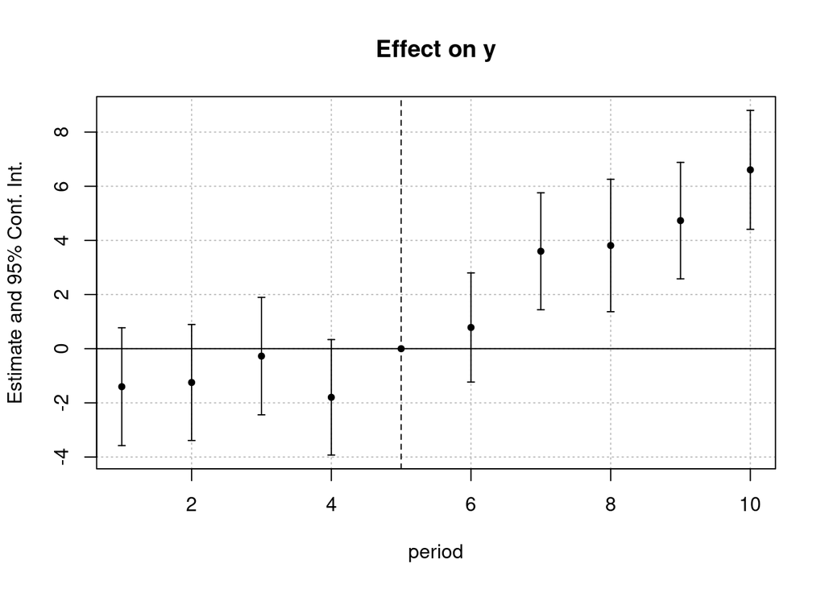

```r
iplot(est_did)
```